# TF-ID & Visualization

B05401102

2018年10月17日

#### **主題**：PubMed網站上Nature雜誌的文字變化分析

#### **文字資料來源**：[PubMed(query=“Nature Journal”)](https://www.ncbi.nlm.nih.gov/pubmed?term=%22Nature%22%5BJournal%5D)

#### **說明**：

- PubMed為美國國家醫學圖書館的生技資訊中心(NCBI)所製作的生物醫學相關文獻的書目索引摘要資料庫。文章、論文的範圍以生物醫學方面為主。
- Nature是是全世界最權威及最有名望的學術期刊之一，發表來自很多科學領域的一手研究論文的期刊。。
- 此次作業的目的是要分析PubMed網站上Nature論文的abstract，比較論文內容的變化趨勢。

### **1. Data Input**

> PubMed網站提供相當方便的檢索論文方式。步驟為：
1. 在搜尋引擎中輸入**“Nature”[Journal]**就可以找到所有Nature雜誌的文章。
2. 選擇日期範圍，並選擇abstract，就會列出所有abstract的文章。我下載了**1970/1980/1990/2000/2010/2017**這六年的文字資料。
3. 點選**send to**→**file**，並直接下載，就可以得到txt.檔。

> 叫出packages並輸入data。

```r
library(NLP)
library(tm)
library(stats)
library(dplyr)
```

```r
library(readtext)
library(slam)
library(Matrix)
library(tidytext)
library(stringr)
library(wordcloud2)
library(ggplot2)
library(rvest)
library(SnowballC)
library(wordcloud2)

#輸入文字data
filesToProcess <- list.files("pubmed_by_10",pattern = "\\.txt$")
filesToProcess
```

```
## [1] "1970pubmed_result.txt" "1980pubmed_result.txt" "1990pubmed_result.txt"
## [4] "2000pubmed_result.txt" "2010pubmed_result.txt" "2017pubmed_result.txt"
```

```r
filesToProcess <- paste0("pubmed_by_10/",filesToProcess)
all.text <- do.call("rbind", lapply(filesToProcess, readtext))
```

### **2. Data processing**

> 同上個禮拜製造文字雲的方式，將文本拆解進行文字分割，整理成詞頻矩陣。

```r
docs = Corpus(VectorSource(all.text))
toSpace <- content_transformer(function(x, pattern) {
  return (gsub(pattern, " ", x))
})
docs <- tm_map(docs, removePunctuation)
docs <- tm_map(docs, removeNumbers)
docs <- tm_map(docs, stripWhitespace)
docs <- tm_map(docs, content_transformer(tolower))

tokenizer = function(d){
  unlist(strsplit(d[[1]], split = " "))
}
seg = lapply(docs, tokenizer)

d.corpus <- Corpus(VectorSource(seg))
tdm <- TermDocumentMatrix(d.corpus)
tf <- as.matrix(tdm)
DF <- tidy(tf)
head(DF)
```

```
## # A tibble: 6 x 7
##   .rownames     X1    X2    X3    X4    X5    X6
##   <chr>      <dbl> <dbl> <dbl> <dbl> <dbl> <dbl>
## 1 about          4    65    68   152   130   164
## 2 above          1    13     7    26    30    26
## 3 abscisic       1     0     0     2     0     0
## 4 abscission     2     0     0     6     0     0
## 5 absolute       1     3     1     5     9     3
## 6 absorption     2    17     9    18     8    31
```

> 利用tf-idf將具有代表意義的字詞進行加權，顯示部分結果並輸出`show1970-2017.csv`。

```r
# tf-idf computation
N = tdm$ncol
tf <- apply(tdm, 2, sum)
idfCal <- function(word_doc)
{
  log2( N / nnzero(word_doc) )
}
idf <- apply(tdm, 1, idfCal)

doc.tfidf <- as.matrix(tdm)
for(x in 1:nrow(tdm))
{
  for(y in 1:ncol(tdm))
  {
    doc.tfidf[x,y] <- (doc.tfidf[x,y] / tf[y]) * idf[x]
  }
}

findZeroId = as.matrix(apply(doc.tfidf, 1, sum))
tfidfnn = doc.tfidf[-which(findZeroId == 0),]

#顯示tfidf後的結果
head(tfidfnn)
```

```
##               Docs
## Terms                     1            2            3            4
##   abscisic     3.447819e-04 0.000000e+00 0.000000e+00 1.879867e-05
##   abscission   6.895638e-04 0.000000e+00 0.000000e+00 5.639600e-05
##   academy      5.721871e-05 0.000000e+00 5.408447e-06 3.119756e-06
##   acceleration 5.721871e-05 5.874188e-06 0.000000e+00 4.679634e-06
##   accounting   5.721871e-05 2.937094e-06 0.000000e+00 9.359267e-06
##   adapting     5.721871e-05 5.874188e-06 2.704223e-06 3.119756e-06
##               Docs
## Terms                     5            6
##   abscisic     0.000000e+00 0.000000e+00
##   abscission   0.000000e+00 0.000000e+00
##   academy      5.448836e-06 1.082280e-04
##   acceleration 9.535464e-06 1.213772e-05
##   accounting   6.811046e-06 6.068858e-06
##   adapting     2.724418e-06 0.000000e+00
```

```r
#輸出詞頻矩陣
write.csv(tfidfnn, "show1970-2017.csv")
```

### **3. Plotting**

> 建立字詞(Var1)與字詞頻率(Freq)的data frame，並刪除一些沒有比較意義的單字，依照字詞出現頻率進行排序。

```r
freqFrame.all<-list()
excludeWords <- c("nature","doi","pmid","university","department","pmc","pmcid","epub","institute","index", "author", "science", "can", "new", "research", "school")
for(i in 1:6){
  f = as.data.frame(table(seg[[i]]))
  freqFrameClean<- f[-which(f$Var1 %in% stopwords("en")),]
  freqFrameClean<- freqFrameClean[-which(freqFrameClean$Var1 %in% excludeWords),]
  freqFrameClean<- freqFrameClean[-which(nchar(as.character(freqFrameClean$Var1))<3),]
  freqFrame.all[[i]] <- freqFrameClean[order(freqFrameClean$Freq, decreasing = T),]
}
names(freqFrame.all) <- c("1970","1980","1990","2000","2010","2017" )

#以2017年的frequency dataframe為例，製作文字雲
head(freqFrame.all[[6]])
```

```
##              Var1 Freq
## 31678         usa 2839
## 4730       center 1132
## 4159   california  985
## 18706    medicine  967
## 4694        cells  955
## 14436 information  943
```

```r
wordcloud2(data = freqFrame.all[[6]], size=0.5)
```

[interactive chart not shown]

> 為了比較出不同年份的文字在生物領域上有什麼具有意義的差別，因此我利用爬蟲到wikipedia的glossary上擷取biology terms，篩選出這些terms對應的頻率。

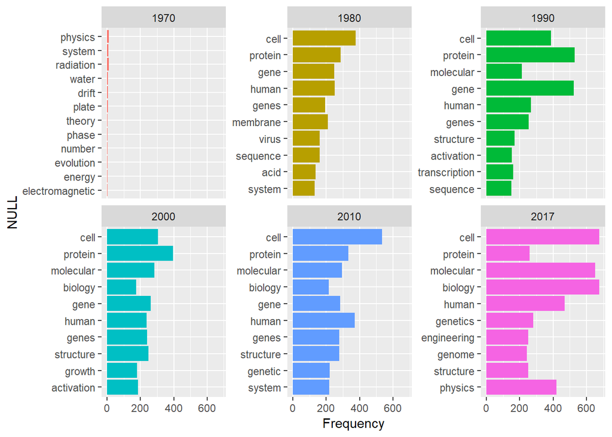

```r
bioterm <- read_html("https://en.wikipedia.org/wiki/Glossary_of_biology#D") %>% html_nodes(".glossary .glossary .glossary a") %>% html_text()
splitBioterm <- unlist(strsplit(bioterm," "))

#創建只包含biology terms的新frequency dataframe
freqFrame.bio <- data.frame()
for(i in 1:6){
  addfreqFrame.bio <- freqFrame.all[[i]][which(freqFrame.all[[i]]$Var1 %in% splitBioterm),]
  addfreqFrame.bio$year <- rep(names(freqFrame.all)[i],nrow(addfreqFrame.bio))
  freqFrame.bio <- rbind(freqFrame.bio, addfreqFrame.bio)
}
freqFrame.bio$year <- as.factor(freqFrame.bio$year)
freqFrame.bio$Var1 <- as.character(freqFrame.bio$Var1)
#作圖
word_by_year <- freqFrame.bio %>%
        group_by(year) %>%
        top_n(10,Freq) %>%
        ggplot(aes(x = reorder(Var1,Freq), y = Freq, fill = year )) +
          geom_bar(stat = "identity") +
          facet_wrap(~ year, scales = "free_y") +
          labs(x = "NULL", y = "Frequency") +
          coord_flip() +
          theme(legend.position="none")
word_by_year
```

### **4. Intepretation**

> 從這張圖表可以做出一些推論。
1. cell, protein, gene, molecular是近50年來最熱門的議題。
2. 1970年的內容比較不一樣，原因值得探討。
3. molecular biology出現頻率有越來越多的趨勢。
4. virus的研究在1980年代比較熱門，分子生物學的基礎–transcription 和 activation 則在1990年代被廣泛研究。
5. 若要進行更精確的趨勢分析，可能還需要下載更多data，縮短年份的間隔。